# Figure 1: overview

Figure 1 for one grouping: who is compared (panel a), then the whole-proteome picture before any single result. It reads saved outputs only. The one computation is the phenotype PCA, a projection with no test; every p value drawn comes from `02_Protein_Contrasts` or `03_Set_Contrasts`.

| panel | shows |
| --- | --- |
| a | HR/LR: the BioRender design panel. Clusterings: each person in the space they were clustered in |
| b | proteins per contrast and direction at Π < 0.05, p < 0.05 and BH < 0.05 |
| c | proteome PCA and phenotype PCA, with PERMANOVA |
| d | selected gene sets across the nine contrasts (fgsea NES and FDR) |
| e, f | each group’s training and acute sets, ranked in the other group (fry) |

`build_group_overview()` (shared helper, `00_Setup/Shared_functions/group_overview_figure.R`) assembles panels b to f, checks every plotted number against its source table, writes `b_reports/<stem>.pdf` and `c_data/<stem>.xlsx`, and returns the figure.

## Packages

```r
library(here)
library(dplyr)
library(tidyr)
library(purrr)
library(tibble)
library(ggplot2)
library(patchwork)
source(here("00_Setup", "Shared_functions", "analysis_reporting_helpers.R"))
source(here("00_Setup", "Shared_functions", "figure_style.R"))
source(here("00_Setup", "Shared_functions", "figure_panels.R"))
source(here("00_Setup", "Shared_functions", "group_overview_figure.R"))
source(here("00_Setup", "Shared_functions", "proteome_inputs.R"))
params$grouping
```

```
[1] "Muscle_size"
```

`figure_inputs()` takes a grouping and, for the Proteome grouping, a clustering input, and returns the named file paths the figure reads.

```r
figure_inputs <- function(grouping, input = NULL) {
  step <- \(name) paste(c("03_Group_comparisons", grouping, name, input), collapse = "/")
  c(
    contrasts = file.path(step("02_Protein_Contrasts"), "c_data/protein_contrasts.xlsx"),
    set_tests = file.path(step("03_Set_Contrasts"), "c_data/set_tests.rds"),
    gene_sets = "01_Processing/04_Gene_Sets/c_data/gene_sets.rds",
    phenotype = "00_Setup/Input/phenotype.csv",
    if (grouping == "HRvLR") {
      c(design = "05_Figures/HRvLR/F1_Overview/assets/design.png")
    } else {
      c(
        clustering = file.path("02_Groups", grouping, "c_data/clustering.xlsx"),
        design = file.path(step("01_Design_Contrasts"), "c_data/design.rds")
      )
    }
  )
}
out_dir <- here("05_Figures", params$grouping, "F1_Overview")
```

## HR and LR

Panel a is the BioRender design panel, pinned under its title so it sits level with b and c.

```r
inputs <- figure_inputs("HRvLR")
paths <- map_chr(inputs, here)
stopifnot(file.exists(paths))
panel_design <- ggplot() +
  annotation_custom(grid::rasterGrob(
    png::readPNG(paths[["design"]]),
    y = grid::unit(1, "npc"), just = "top", interpolate = TRUE
  )) +
  labs(
    title = "Design and contrasts",
    subtitle = "16 adults, 45 biopsies; contrast colours carry through b to f"
  ) +
  theme_void(base_size = 7) +
  theme(
    plot.title = figure_theme$plot.title, plot.subtitle = figure_theme$plot.subtitle,
    plot.title.position = "plot"
  )
build_group_overview(
  panel_design, inputs, paths,
  groups = c("HR", "LR"), out_dir = out_dir, stem = "f1_overview",
  note = "Panel a is the BioRender design panel (assets/design.png); it reads no data."
) |>
  print()
```

## Muscle size and muscle strength clusters

Panel a shows each person on the first two components of the traits they were clustered on, with the gap statistic’s K, the K used and each group’s bootstrap Jaccard.

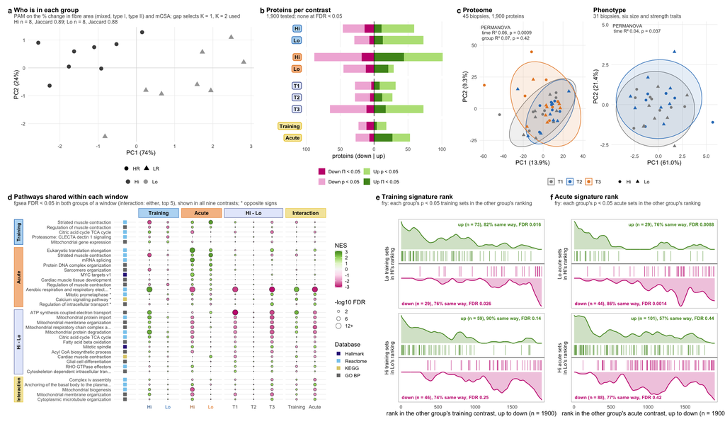

Figure 1: Figure 1 for a phenotype clustering.

```r
inputs <- figure_inputs(params$grouping)
paths <- map_chr(inputs, here)
stopifnot(file.exists(paths))
read_clustering <- \(sheet) readxl::read_excel(paths[["clustering"]], sheet)
groups <- c("Hi", "Lo")
clustered_on <- c(
  Muscle_size = "the % change in fibre area (mixed, type I, type II) and mCSA",
  Muscle_strength = "the % change in leg-press and leg-extension 1RM"
)[[params$grouping]]
clustering <- panel_clustering(
  read_clustering("space"), read_clustering("space_variance"), read_clustering("choice"),
  read_clustering("stability"), groups,
  clustered_on = clustered_on
)
build_group_overview(
  clustering$plot, inputs, paths,
  groups = groups, out_dir = out_dir, stem = "f1_overview",
  a_sheets = list(clustering = clustering$data),
  a_holds = "Panel a: each person's cluster, HR/LR and PC1 and PC2 of the scaled traits.",
  group_of = readRDS(paths[["design"]])$group_of
) |>
  print()
```

## Proteome clusters

One figure per clustering input. Each contrast’s label carries its validity against that clustering: circ. (circular, built from the same time points) or caut. (caution, shares a time point).

```r
groups <- c("C1", "C2")
clustered_on <- c(
  T1 = "the T1 module eigengenes", T2 = "the T2 module eigengenes",
  T3 = "the T3 module eigengenes", training = "the training change in module eigengenes",
  acute = "the acute change in module eigengenes"
)
walk(inputs_used, \(input) {
  inputs <- figure_inputs("Proteome", input)
  paths <- map_chr(inputs, here)
  stopifnot(file.exists(paths))
  read_clustering <- \(sheet) {
    readxl::read_excel(paths[["clustering"]], sheet) |> filter(.data$input == .env$input)
  }
  space <- read_clustering("space") |> mutate(group = paste0("C", cluster))
  clustering <- panel_clustering(
    space, read_clustering("space_variance"), read_clustering("choice"),
    read_clustering("stability"), groups, clustered_on[[input]]
  )
  contrasts <- as.character(overview_contrasts(groups)$contrast)
  build_group_overview(
    clustering$plot + labs(title = sprintf("Who is in each group, clustered at %s", input)),
    inputs, paths,
    groups = groups, out_dir = out_dir, stem = paste0("f1_overview_", input),
    a_sheets = list(clustering = clustering$data),
    a_holds = "Panel a: each person's cluster, HR/LR and PC1 and PC2 of the eigengenes.",
    validity = set_names(validity(input, contrasts), contrasts),
    group_of = readRDS(paths[["design"]])$group_of
  ) |>
    print()
})
```